# Systemy Decyzyjne 2023/2024

Laboratorium 6 - biblioteki do trenowania sieci neuronowych: Tensorflow i Keras

Andrzej Janusz

## Klasyfikacja obrazków

Klasyfikacja obrazów to jedna z domen, w której od kilku lat niepodzielnie rządzą sieci neuronowe. Poniższe przykłady demonstrują jak proste jest konstruowanie sieci, zarówno gęstych jak i konwolucyjnych, za pomocą *Keras Sequential API*. Bazują one na tutorialach dostępnych na: https://tensorflow.rstudio.com/tutorials

Wykorzystamy popularny zbiór benchmarkowy dla problemu klasyfikacji obrazów - CIFAR10.

```r
# Wczytywanie danych:
if (file.exists("cifar.RData")) {
   load("cifar.RData")
} else {
  cifar <- dataset_cifar10()
  save(cifar, file = "cifar.RData")
}
?load


# wyodrębmy zbiór treningowy oraz testowy
train_images <- cifar$train$x
train_labels <- cifar$train$y

dim(train_images)
```

```
[1] 50000    32    32     3
```

```r
dim(train_labels)
```

```
[1] 50000     1
```

```r
# alternatywnie, powyższą operację możemy tez zapisać jako:
c(test_images, test_labels) %<-% cifar$test

dim(test_images)
```

```
[1] 10000    32    32     3
```

```r
dim(test_images)
```

```
[1] 10000    32    32     3
```

```r
class_names <- c('airplane', 'automobile', 'bird', 'cat', 'deer',
                 'dog', 'frog', 'horse', 'ship', 'truck')
```

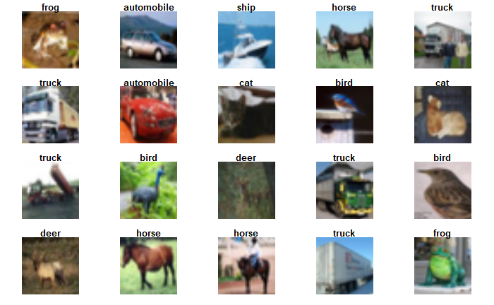

```r
# możemy sprawdzić, czy etykiety mają sens
idx <- 1:20

par(mfcol = c(4,5), mar = rep(1, 4), oma = rep(0.2, 4))
train_images[idx,,,] %>%
  purrr::array_tree(1) %>%
  purrr::set_names(class_names[train_labels[idx] + 1]) %>%
  purrr::map(as.raster, max = 255) %>%
  purrr::iwalk(~{plot(.x); title(.y)})
```

W pierwszej kolejności, spróbujmy wytrenować klasyczną wielowarstwową gęstą sieć neuronową.

```r
# Zaczniemy od przeskalowania tensorów z bitmapami, tak by zawierały wartości z przedziału [0, 1]
train_images <- train_images / 255
test_images <- test_images / 255

# teraz możemy zdefiniować model wykorzystując Keras Sequential API
dense_model <- keras_model_sequential()
```

```
2023-11-25 23:43:17.608315: I tensorflow/core/platform/cpu_feature_guard.cc:182] This TensorFlow binary is optimized to use available CPU instructions in performance-critical operations.
To enable the following instructions: SSE SSE2 SSE3 SSE4.1 SSE4.2 AVX AVX2 FMA, in other operations, rebuild TensorFlow with the appropriate compiler flags.
```

```r
# pierwsza warstwa 'spłaszcza' obrazki, dalej mamy dwie warstwy ukryte z aktywacją 'relu' i warstwę wyjściową
dense_model %>%
  layer_flatten(input_shape = c(32, 32, 3)) %>%
  layer_dense(units = 128, activation = 'relu') %>%
  layer_dense(units = 128, activation = 'relu') %>%
  layer_dense(units = 10, activation = 'softmax')

summary(dense_model)
```

```
Model: "sequential"
_____________________________________________________________________________________________________________________
 Layer (type)                                       Output Shape                                   Param #
=====================================================================================================================
 flatten (Flatten)                                  (None, 3072)                                   0
 dense_2 (Dense)                                    (None, 128)                                    393344
 dense_1 (Dense)                                    (None, 128)                                    16512
 dense (Dense)                                      (None, 10)                                     1290
=====================================================================================================================
Total params: 411146 (1.57 MB)
Trainable params: 411146 (1.57 MB)
Non-trainable params: 0 (0.00 Byte)
_____________________________________________________________________________________________________________________
```

```r
# po zdefiniowaniu modelu musimy go zainicjować
dense_model %>% compile(
  optimizer = 'adam',
  loss = 'sparse_categorical_crossentropy',
  metrics = c('accuracy')
)
```

```r
# zdefiniowany model należy wytrenować
dense_model %>% fit(train_images, train_labels,
                    epochs = 10,
                    validation_data = list(test_images, test_labels),
                    verbose = 2)
```

```
1563/1563 - 11s - loss: 1.8476 - accuracy: 0.3318 - val_loss: 1.7218 - val_accuracy: 0.3781 - 11s/epoch - 7ms/step
1563/1563 - 8s - loss: 1.6782 - accuracy: 0.3986 - val_loss: 1.6455 - val_accuracy: 0.4085 - 8s/epoch - 5ms/step
1563/1563 - 8s - loss: 1.6098 - accuracy: 0.4233 - val_loss: 1.5895 - val_accuracy: 0.4273 - 8s/epoch - 5ms/step
1563/1563 - 8s - loss: 1.5746 - accuracy: 0.4356 - val_loss: 1.5708 - val_accuracy: 0.4381 - 8s/epoch - 5ms/step
1563/1563 - 8s - loss: 1.5426 - accuracy: 0.4455 - val_loss: 1.6063 - val_accuracy: 0.4316 - 8s/epoch - 5ms/step
1563/1563 - 9s - loss: 1.5187 - accuracy: 0.4550 - val_loss: 1.5220 - val_accuracy: 0.4544 - 9s/epoch - 6ms/step
1563/1563 - 9s - loss: 1.5004 - accuracy: 0.4596 - val_loss: 1.5144 - val_accuracy: 0.4646 - 9s/epoch - 6ms/step
1563/1563 - 8s - loss: 1.4828 - accuracy: 0.4664 - val_loss: 1.4758 - val_accuracy: 0.4680 - 8s/epoch - 5ms/step
1563/1563 - 8s - loss: 1.4730 - accuracy: 0.4707 - val_loss: 1.5293 - val_accuracy: 0.4491 - 8s/epoch - 5ms/step
1563/1563 - 8s - loss: 1.4594 - accuracy: 0.4753 - val_loss: 1.5358 - val_accuracy: 0.4544 - 8s/epoch - 5ms/step
```

```r
# możemy sprawdzić jak dobrze radzi sobie model na zbiorze testowym
dense_score <- evaluate(dense_model, test_images, test_labels, verbose = 0)

cat('Test loss:', dense_score["loss"], "\n")
```

```
Test loss: 1.535781
```

```r
cat('Test accuracy:', dense_score["accuracy"], "\n")
```

```
Test accuracy: 0.4544
```

```r
# predykcje modelu możemy uzyskać wykorzystując metodę predict
predictions <- predict(dense_model, test_images)
head(predictions)
```

```
            [,1]        [,2]        [,3]        [,4]         [,5]         [,6]         [,7]       [,8]        [,9]
[1,] 0.010428907 0.169963017 0.025113851 0.457704127 0.0362510569 0.1756515801 1.130993e-02 0.01263417 0.029056557
[2,] 0.063944504 0.403366089 0.001927266 0.001139805 0.0005669785 0.0004744619 6.589560e-05 0.00222707 0.174111411
[3,] 0.206371814 0.161971048 0.004788707 0.004015902 0.0015813846 0.0035194738 8.009793e-05 0.02352181 0.250067264
[4,] 0.276416570 0.073582470 0.097410060 0.013282012 0.0366957895 0.0190301631 2.869787e-04 0.19522218 0.124221824
[5,] 0.006537334 0.001419554 0.044592477 0.038720001 0.7263437510 0.0600603148 1.056234e-01 0.01157110 0.004411997
[6,] 0.045197356 0.040045142 0.055537749 0.139552251 0.0597394407 0.0612939298 5.135963e-01 0.07026283 0.003862620
            [,10]
[1,] 0.0718868375
[2,] 0.3521764874
[3,] 0.3440825343
[4,] 0.1638518870
[5,] 0.0007200019
[6,] 0.0109123802
```

```r
which.max(predictions[1, ]) - 1
```

```
[1] 3
```

```r
# możemy też użyć metody z tensorflow by uzyskać przewidziane klasy
class_pred <-  k_argmax(predictions)
as.integer(class_pred[1])
```

```
[1] 3
```

Klasyczna gęsta sieć neuronowa nie jest w stanie uczyć się rozpoznawać wzorce mogące występować w różnych miejscach na obrazku. Rozwiązanie tego problemu jest głównym zadaniem dla konwolucyjnych sieci neuronowych (CNN).

```r
# zdefiniujmy teraz sieć konwolucyjną wykorzystuąc częsty wzorzec - naprzemiennie ułożone warstwy konwolucyjne oraz 'pooling'
conv_model <- keras_model_sequential(name = "conv1")

conv_model %>%
  layer_conv_2d(filters = 32, kernel_size = c(3,3), activation = "relu",
                input_shape = c(32,32,3)) %>%
  layer_max_pooling_2d(pool_size = c(2,2)) %>%

  layer_conv_2d(filters = 64, kernel_size = c(3,3), activation = "relu") %>%
  layer_max_pooling_2d(pool_size = c(2,2)) %>%

  layer_conv_2d(filters = 64, kernel_size = c(3,3), activation = "relu")

summary(conv_model)
```

```
Model: "conv1"
_____________________________________________________________________________________________________________________
 Layer (type)                                       Output Shape                                   Param #
=====================================================================================================================
 conv2d_2 (Conv2D)                                  (None, 30, 30, 32)                             896
 max_pooling2d_1 (MaxPooling2D)                     (None, 15, 15, 32)                             0
 conv2d_1 (Conv2D)                                  (None, 13, 13, 64)                             18496
 max_pooling2d (MaxPooling2D)                       (None, 6, 6, 64)                               0
 conv2d (Conv2D)                                    (None, 4, 4, 64)                               36928
=====================================================================================================================
Total params: 56320 (220.00 KB)
Trainable params: 56320 (220.00 KB)
Non-trainable params: 0 (0.00 Byte)
_____________________________________________________________________________________________________________________
```

```r
# następnie, dodajmy jedną gęstą warstwę ukrytą i warstwę wyjściową
conv_model %>%
  layer_flatten() %>%
  layer_dense(units = 16, activation = "relu") %>%
  layer_dense(units = 10, activation = "softmax")

summary(conv_model)
```

```
Model: "conv1"
_____________________________________________________________________________________________________________________
 Layer (type)                                       Output Shape                                   Param #
=====================================================================================================================
 conv2d_2 (Conv2D)                                  (None, 30, 30, 32)                             896
 max_pooling2d_1 (MaxPooling2D)                     (None, 15, 15, 32)                             0
 conv2d_1 (Conv2D)                                  (None, 13, 13, 64)                             18496
 max_pooling2d (MaxPooling2D)                       (None, 6, 6, 64)                               0
 conv2d (Conv2D)                                    (None, 4, 4, 64)                               36928
 flatten_1 (Flatten)                                (None, 1024)                                   0
 dense_4 (Dense)                                    (None, 16)                                     16400
 dense_3 (Dense)                                    (None, 10)                                     170
=====================================================================================================================
Total params: 72890 (284.73 KB)
Trainable params: 72890 (284.73 KB)
Non-trainable params: 0 (0.00 Byte)
_____________________________________________________________________________________________________________________
```

```r
# inicjalizacja modelu - tak samo jak poprzednio
conv_model %>% compile(
  optimizer = optimizer_adam(learning_rate = 0.001),
  loss = "sparse_categorical_crossentropy",
  metrics = list("accuracy")
)
```

```r
# Możemy zapisać i zwizualizować przebieg procesu trenowania
training_process <-  fit(conv_model,
                         x = train_images, y = train_labels,
                         epochs = 20,
                         validation_data = list(test_images, test_labels),
                         verbose = 2)
```

```
1563/1563 - 36s - loss: 1.5806 - accuracy: 0.4199 - val_loss: 1.4049 - val_accuracy: 0.4949 - 36s/epoch - 23ms/step
1563/1563 - 29s - loss: 1.2118 - accuracy: 0.5666 - val_loss: 1.1362 - val_accuracy: 0.6006 - 29s/epoch - 19ms/step
1563/1563 - 29s - loss: 1.0626 - accuracy: 0.6260 - val_loss: 1.0015 - val_accuracy: 0.6506 - 29s/epoch - 18ms/step
1563/1563 - 29s - loss: 0.9614 - accuracy: 0.6627 - val_loss: 1.0057 - val_accuracy: 0.6536 - 29s/epoch - 19ms/step
1563/1563 - 28s - loss: 0.8921 - accuracy: 0.6892 - val_loss: 0.9119 - val_accuracy: 0.6796 - 28s/epoch - 18ms/step
1563/1563 - 28s - loss: 0.8390 - accuracy: 0.7053 - val_loss: 0.8934 - val_accuracy: 0.6878 - 28s/epoch - 18ms/step
1563/1563 - 28s - loss: 0.7911 - accuracy: 0.7223 - val_loss: 0.9054 - val_accuracy: 0.6911 - 28s/epoch - 18ms/step
1563/1563 - 29s - loss: 0.7483 - accuracy: 0.7384 - val_loss: 0.9042 - val_accuracy: 0.6922 - 29s/epoch - 18ms/step
1563/1563 - 28s - loss: 0.7153 - accuracy: 0.7484 - val_loss: 0.8579 - val_accuracy: 0.7072 - 28s/epoch - 18ms/step
1563/1563 - 28s - loss: 0.6866 - accuracy: 0.7601 - val_loss: 0.8669 - val_accuracy: 0.7069 - 28s/epoch - 18ms/step
1563/1563 - 28s - loss: 0.6587 - accuracy: 0.7682 - val_loss: 0.8769 - val_accuracy: 0.7019 - 28s/epoch - 18ms/step
1563/1563 - 28s - loss: 0.6297 - accuracy: 0.7777 - val_loss: 0.8818 - val_accuracy: 0.7031 - 28s/epoch - 18ms/step
1563/1563 - 28s - loss: 0.6092 - accuracy: 0.7847 - val_loss: 0.8711 - val_accuracy: 0.7128 - 28s/epoch - 18ms/step
1563/1563 - 28s - loss: 0.5860 - accuracy: 0.7935 - val_loss: 0.9207 - val_accuracy: 0.6999 - 28s/epoch - 18ms/step
1563/1563 - 28s - loss: 0.5605 - accuracy: 0.8010 - val_loss: 0.8999 - val_accuracy: 0.7003 - 28s/epoch - 18ms/step
1563/1563 - 29s - loss: 0.5392 - accuracy: 0.8093 - val_loss: 0.8936 - val_accuracy: 0.7112 - 29s/epoch - 19ms/step
1563/1563 - 28s - loss: 0.5163 - accuracy: 0.8170 - val_loss: 0.9361 - val_accuracy: 0.7051 - 28s/epoch - 18ms/step
1563/1563 - 27s - loss: 0.5000 - accuracy: 0.8236 - val_loss: 0.9620 - val_accuracy: 0.7038 - 27s/epoch - 17ms/step
1563/1563 - 32s - loss: 0.4806 - accuracy: 0.8289 - val_loss: 0.9736 - val_accuracy: 0.7018 - 32s/epoch - 21ms/step
1563/1563 - 31s - loss: 0.4638 - accuracy: 0.8336 - val_loss: 0.9785 - val_accuracy: 0.7118 - 31s/epoch - 20ms/step
```

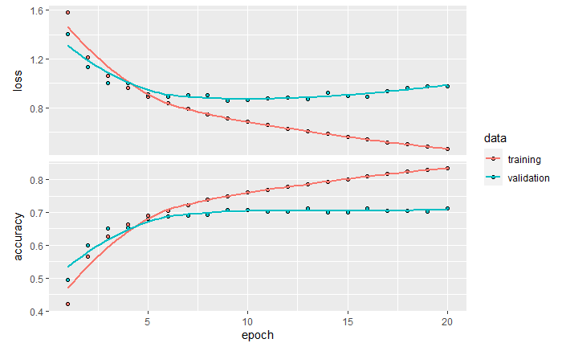

```r
plot(training_process)
```

```r
# ewaluacja na zbiorze testowym
conv_score <- evaluate(conv_model, test_images, test_labels, verbose = 0)

cat('Test loss:', conv_score["loss"], "\n")
```

```
Test loss: 0.9784968
```

```r
cat('Test accuracy:', conv_score["accuracy"], "\n")
```

```
Test accuracy: 0.7118
```

Warto zauważyć, że jakość modelu konwolucyjnego jest istotnie większa od sieci gęstej mimo, że sieć konwolucyjna ma kilkukrotnie mniejszą liczbę parametrów. Widać także, że sieć konwolucyjna jest o wiele bardziej podatna na przeuczenie (overfitting).

W praktyce, często dobrym pomysłem jest dodanie warstw regulujących wagi sieci, np. *layer_spatial_dropout_2d* oraz normalizować paczki danych przez *layer_batch_normalization*.

## Zadanie

Proszę spróbować poprawić działanie sieci konwolucyjnej przez dodanie regularyzacji oraz poeksperymentowanie z architekturą i hiperparametrami modelu.

```r
# to jest miejsce na rozwiazanie zadania:
```